# Homework 4

Homework 4

Joe Davis  
4/17/2022

```r
knitr::opts_chunk$set(include = TRUE)
library(tidyverse)
library(smss)
library(alr4)
library(corrplot)
library(MASS)
library(broom)
```

## Part One

### Question 1

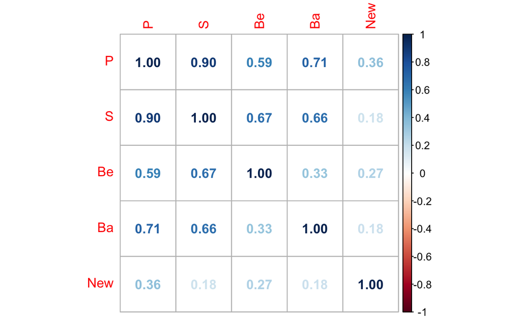

```r
#Reproduce the Correlation Plot
data(house.selling.price.2)
house_dat <- house.selling.price.2
house_corr_dat <- cor(round(house_dat,2))
house_corr_plot <- corrplot(house_corr_dat, method = "number")
```

```r
#Reproduce the Initial Model
full_house_model <- lm(P ~ ., data = house_dat)
summary(full_house_model)
```

```
Call:
lm(formula = P ~ ., data = house_dat)

Residuals:
    Min      1Q  Median      3Q     Max
-36.212  -9.546   1.277   9.406  71.953

Coefficients:
            Estimate Std. Error t value Pr(>|t|)
(Intercept)  -41.795     12.104  -3.453 0.000855 ***
S             64.761      5.630  11.504  < 2e-16 ***
Be            -2.766      3.960  -0.698 0.486763
Ba            19.203      5.650   3.399 0.001019 **
New           18.984      3.873   4.902  4.3e-06 ***
---
Signif. codes:  0 '***' 0.001 '**' 0.01 '*' 0.05 '.' 0.1 ' ' 1

Residual standard error: 16.36 on 88 degrees of freedom
Multiple R-squared:  0.8689,    Adjusted R-squared:  0.8629
F-statistic: 145.8 on 4 and 88 DF,  p-value: < 2.2e-16
```

-*A)For backward elimination, which variable would be deleted first? Why?*

For backward elimination, the `Beds` variable would be the first to be removed. This is because of the large `P-value` seen for that variable in the model looking at all of the variables of `.487`.

-*B) For forward selection, which variable would be added first? Why?*

For forward selection, the variable `Size` would be the first one to add to the model, as it has the highest correlation with our outcome variable of `Price`.

-*C) Why do you think that BEDS has such a large P-value in the multiple regression model, even though it has a substantial correlation with PRICE?*

I think this is because the `Size` variable is capturing most of what the `Beds` variable would be describing, as those two variables are correlated with each other at `.669` in the matrix, the third highest correlation between all of the variables. The `Baths` variable has a similar sort of pattern and likely relates to the number of `Beds` too, however given the specialty build outs needed for bathrooms versus the relatively easy process of converting space to another bedroom, that variable seems to carry extra signal that wouldn’t be covered by its square footage alone.

-*D) Using software with these four predictors, find the model that would be selected using each criterion:*

I used the `StepAIC` function from `MASS` below going in the forward variable selection directions per the `SMSS` R software instructional section. I won’t recreate the whole chart as it exists in the book reading section, but most of it is there from forward selection, so I will just select from the final selected model from `StepAIC` versus recreating the chart for all variables and diagnostics.

-*R2*

For `R2` the model that would be best is the `full_house_model` since each variable adds to the value, even if in this case it is a very small value, removing any variables would lower this value.

-*Adjusted R2* For adjusted `R2`, the extra variable penalty drops the full model just below the `house_step_select` model.

-*PRESS* For PRESS, `house_step_select` has the lower PRESS value, so that would be the selection for this criteria as well.

-*AIC* `house_step_select` has the lower `AIC` value so that would be the best model by this criteria.

-*BIC* The `BIC` value for the `house_step_select` model is (below as `step_model_stats`) slightly lower than the full variable model value of `full_model_stats`, so we would select that one.

-*E) Explain which model you prefer and why.*

I would probably want to know more about the use case of the model, as perhaps if we were using this for prediction for unseen data, the beds variable could be useful with changing building codes or other quirks. As is, I would select the more parsimonious with basically the same adjusted R2 value on descriptive power as the full model `house_step_select` model.

```r
#StepAIC in both directions for model selection.
#Need to define the Upper and Lower Scope for foward selection
null_house_model <- lm(P ~ 1, data = house_dat)

house_step_select <- stepAIC(null_house_model, direction = "forward", scope = ~ S + Be + Ba + New)
```

```
Start:  AIC=705.63
P ~ 1

       Df Sum of Sq    RSS    AIC
+ S     1    145097  34508 554.22
+ Ba    1     91484  88121 641.41
+ Be    1     62578 117028 667.79
+ New   1     22833 156772 694.99
<none>              179606 705.63

Step:  AIC=554.22
P ~ S

       Df Sum of Sq   RSS    AIC
+ New   1    7274.7 27234 534.20
+ Ba    1    4475.6 30033 543.30
<none>              34508 554.22
+ Be    1      40.4 34468 556.11

Step:  AIC=534.2
P ~ S + New

       Df Sum of Sq   RSS    AIC
+ Ba    1    3550.1 23684 523.21
+ Be    1     588.8 26645 534.17
<none>              27234 534.20

Step:  AIC=523.21
P ~ S + New + Ba

       Df Sum of Sq   RSS    AIC
<none>              23684 523.21
+ Be    1    130.55 23553 524.70
```

```r
#glance from broom for stats in tidy format
full_model_stats <- glance(full_house_model)
step_model_stats <- glance(house_step_select)

full_model_stats
```

```
# A tibble: 1 × 12
  r.squared adj.r.squared sigma statistic  p.value    df logLik   AIC
      <dbl>         <dbl> <dbl>     <dbl>    <dbl> <dbl>  <dbl> <dbl>
1     0.869         0.863  16.4      146. 5.94e-38     4  -389.  791.
# … with 4 more variables: BIC <dbl>, deviance <dbl>,
#   df.residual <int>, nobs <int>
```

```r
step_model_stats
```

```
# A tibble: 1 × 12
  r.squared adj.r.squared sigma statistic  p.value    df logLik   AIC
      <dbl>         <dbl> <dbl>     <dbl>    <dbl> <dbl>  <dbl> <dbl>
1     0.868         0.864  16.3      195. 4.96e-39     3  -390.  789.
# … with 4 more variables: BIC <dbl>, deviance <dbl>,
#   df.residual <int>, nobs <int>
```

```r
#make the PRESS function

PRESS <- function(linear.model) {
    pr <- residuals(linear.model)/(1 - lm.influence(linear.model)$hat)
    sum(pr^2)
}

#use PRESS on both Models
PRESS(full_house_model)
```

```
[1] 28390.22
```

```r
PRESS(house_step_select)
```

```
[1] 27860.05
```

### Question 2

*“This data set provides measurements of the diameter, height and volume of timber in 31 felled black cherry trees. Note that the diameter (in inches) is erroneously labelled Girth in the data. It is measured at 4 ft 6 in above the ground.”*

*Tree volume estimation is a big deal, especially in the lumber industry. Use the trees data to build a basic model of tree volume prediction. In particular, fit a multiple regression model with the Volume as the outcome and Girth and Height as the explanatory variables*

*Run regression diagnostic plots on the model. Based on the plots, do you think any of the regression assumptions is violated?*

```r
trees_dat <- trees

#The Model
trees_model <- lm(Volume ~ Height + Girth, data = trees_dat)
summary(trees_model)
```

```
Call:
lm(formula = Volume ~ Height + Girth, data = trees_dat)

Residuals:
    Min      1Q  Median      3Q     Max
-6.4065 -2.6493 -0.2876  2.2003  8.4847

Coefficients:
            Estimate Std. Error t value Pr(>|t|)
(Intercept) -57.9877     8.6382  -6.713 2.75e-07 ***
Height        0.3393     0.1302   2.607   0.0145 *
Girth         4.7082     0.2643  17.816  < 2e-16 ***
---
Signif. codes:  0 '***' 0.001 '**' 0.01 '*' 0.05 '.' 0.1 ' ' 1

Residual standard error: 3.882 on 28 degrees of freedom
Multiple R-squared:  0.948, Adjusted R-squared:  0.9442
F-statistic:   255 on 2 and 28 DF,  p-value: < 2.2e-16
```

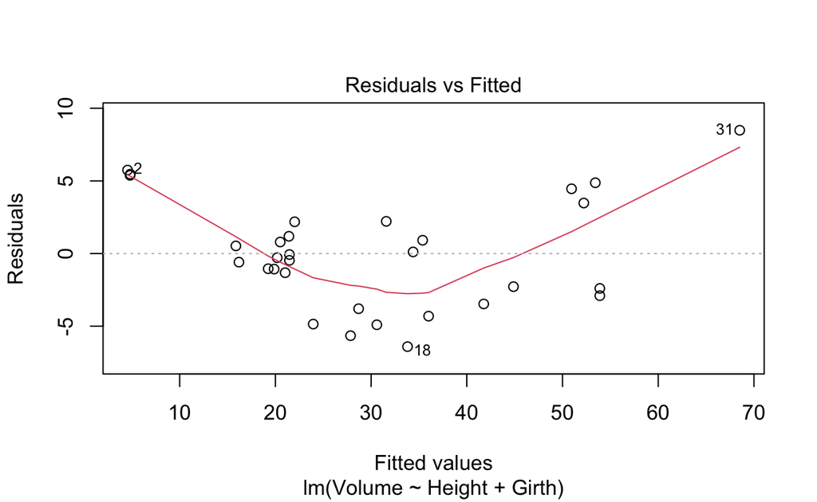

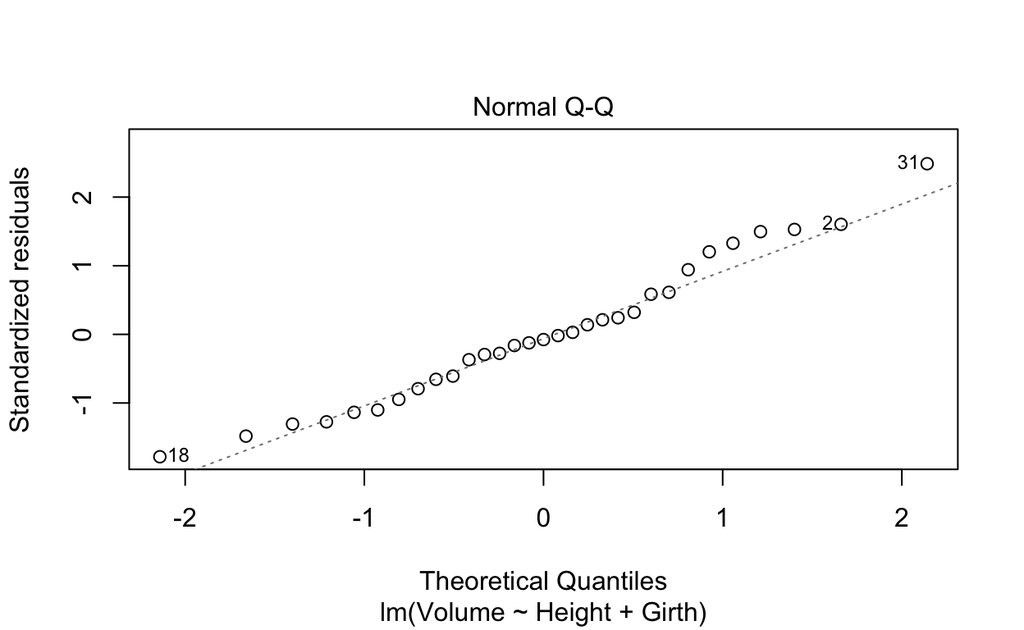

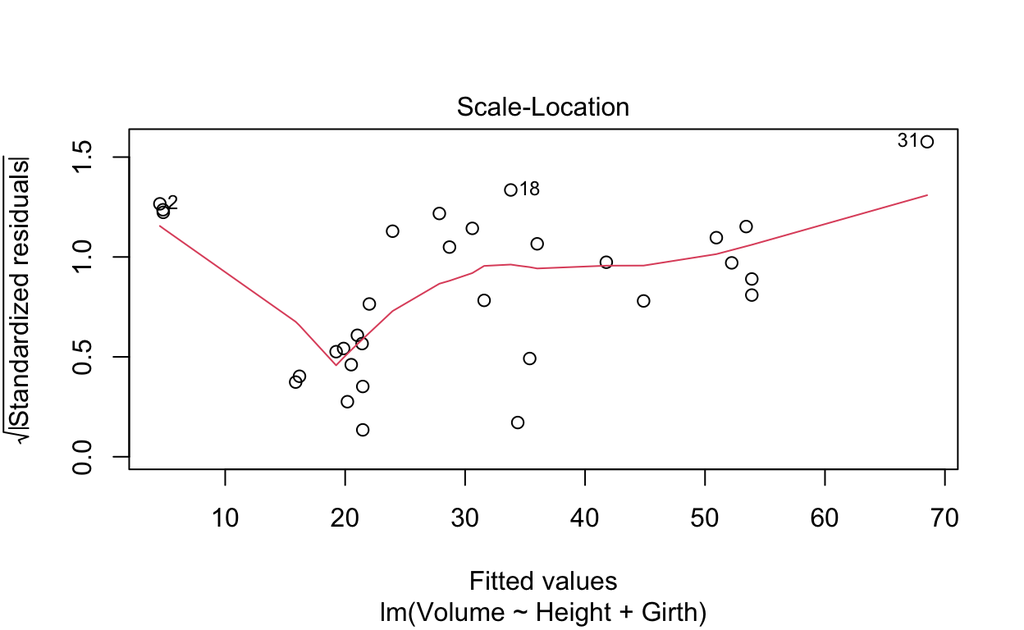

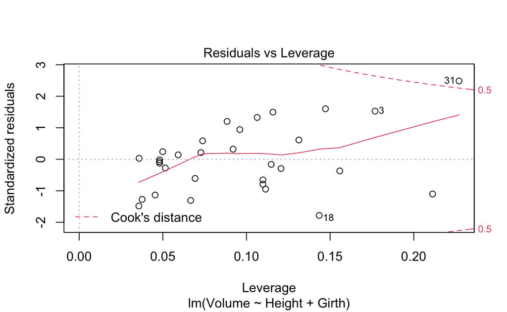

```r
#Diagnostic Plots
plot(trees_model)
```

### Question 3

*In the 2000 election for U.S. president, the counting of votes in Florida was controversial. In Palm Beach County in south Florida, for example, voters used a so-called butterfly ballot. Some believe that the layout of the ballot caused some voters to cast votes for Buchanan when their intended choice was Gore.*

*The data has variables for the number of votes for each candidate—Gore, Bush, and Buchanan. Run a simple linear regression model where the Buchanan vote is the outcome and the Bush vote is the explanatory variable. Produce the regression diagnostic plots. Is Palm Beach County an outlier based on the diagnostic plots? Why or why not?*

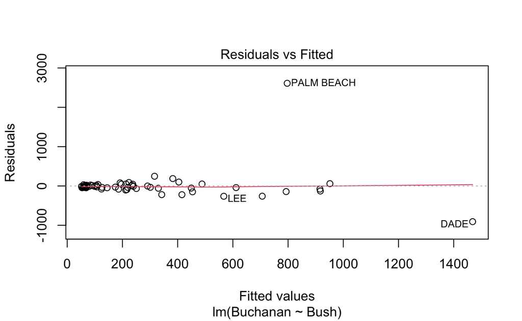

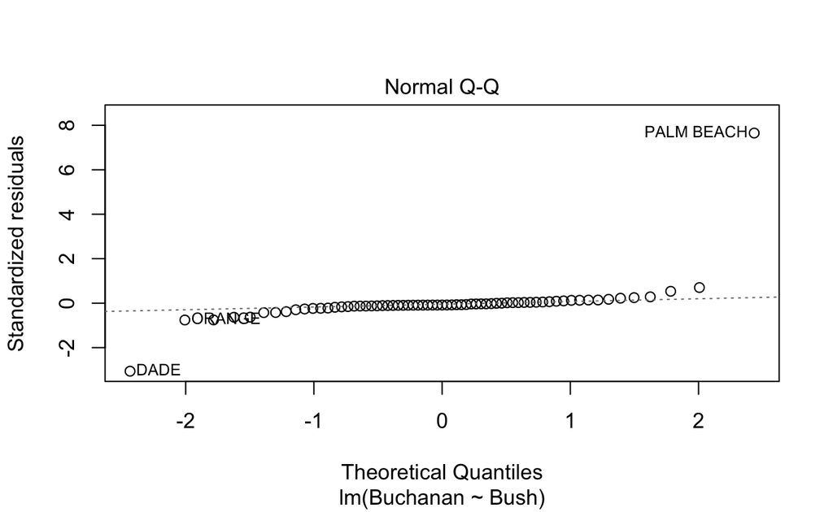

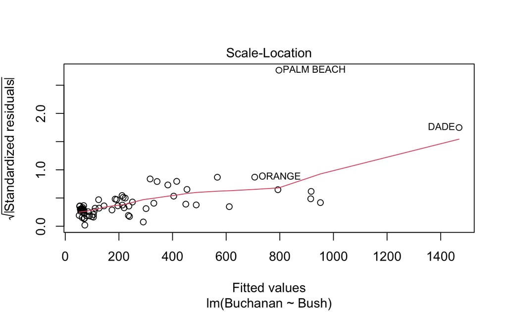

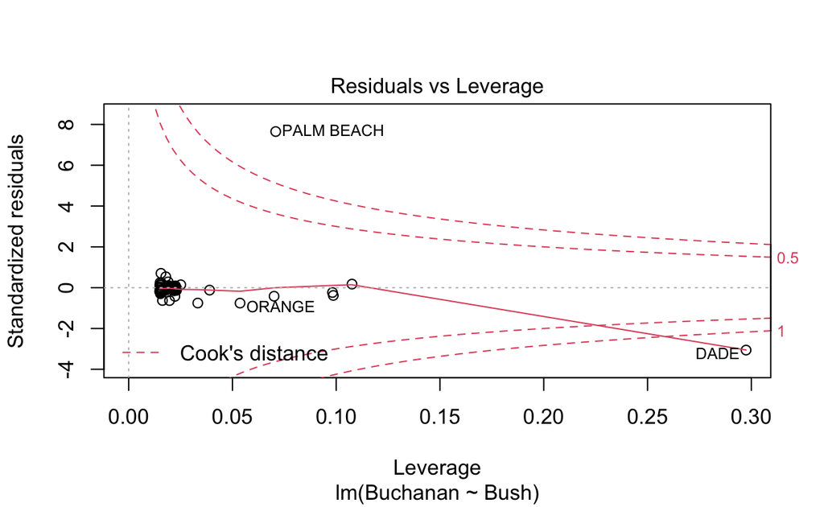

```r
election_dat <- florida
#wow this is still a painful example problem to be honest

election_model <- lm(Buchanan ~ Bush, data = election_dat)
plot(election_model)
```

```r
#wow yep that's painful.
```